# STAT 331 Portfolio

Author

Trenton Tadaki

**My Grade:** I believe my grade equivalent to course work evidenced below to be an A.

**Learning Objective Evidence:** In the code chunks below, provide code from a Lab or Challenge assignment where you believe you have demonstrated proficiency with the specified learning target. Be sure to specify **where** the code came from (e.g., Lab 4 Question 2).

## Working with Data

**WD-1: I can import data from a *variety* of formats (e.g., csv, xlsx, txt, etc.).**

- `csv`

```r
#Lab 2 Set-up

surveys <- read_csv(here("Week 2", "Lab 2", "surveys.csv"))
```

- `xlsx`

```r
#Practice Activity 3 Q1

military <- read_xlsx(here::here("data",                              "gov_spending_per_capita.xlsx"),
                      sheet = "Share of Govt. spending",
                      skip = 7,
                      nmax = 190)
```

- `txt`

```r
#Practice Activity 5.2 Set-up

message <- read_csv(here::here("Week 5",
                                 "Practice Activity 5.2",
                                 "scrambled_message.txt")
                      )
```

**WD-2: I can select necessary columns from a dataset.**

```r
#Challenge 4

avocado_new <- avocado_clean |>
  semi_join(y = cali_regions, by = 'region') |>
  mutate('Avo_sales_USD' = AveragePrice * `Total Volume`,
         'Date' = as.Date(Date),
         'month' = floor_date(Date, 'month')) |>
  select(month,
         Avo_sales_USD,
         region) |>
  group_by(region,
           month) |>
  summarise(Avo_sales_USD = sum(Avo_sales_USD))
```

**WD-3: I can filter rows from a dataframe for a *variety* of data types (e.g., numeric, integer, character, factor, date).**

- numeric

```r
#Lab 3 Q11

hiphop_clean |>
  filter(age < 20) |>
  group_by(word) |>
  summarize(mean_fam = mean(as.numeric(familiarity))) |>
  slice_max(mean_fam)
```

- character – specifically a string

```r
#Practice Activity 5.2 Q2

message |>
  filter(str_detect(Word, pattern = "\\w")) |>
  count()
```

- factor

```r
#Lab 3 Q12

hiphop_clean |>
  filter(ethnic == 'non-white',
         sex == 'Female') |>
  group_by(word) |>
  summarize(mean_fam = mean(as.numeric(familiarity))) |>
  slice_min(mean_fam)
```

- date

```r
#Practice Activity 5.1 Q3

suspects_clean <- suspects_clean |>
  filter(Time.Spotted %within%
           interval(
              start = time_start,
              end = time_end
            )
         )
```

**WD-4: I can modify existing variables and create new variables in a dataframe for a *variety* of data types (e.g., numeric, integer, character, factor, date).**

- numeric

```r
#Challenge 4

avocado_new <- avocado_clean |>
  semi_join(y = cali_regions, by = 'region') |>
  mutate('Avo_sales_USD' = AveragePrice * `Total Volume`,
         'Date' = as.Date(Date),
         'month' = floor_date(Date, 'month')) |>
  select(month,
         Avo_sales_USD,
         region) |>
  group_by(region,
           month) |>
  summarise(Avo_sales_USD = sum(Avo_sales_USD))
```

- character – specifically a string

```r
#Practice Activity 5.2 Part 2 Q4

word_clean <- word_clean |>
      str_replace_all(pattern = "aa",
                      replace = "ee")
```

- factor

```r
#Lab 5 Captures Over the Week Q3

week_day_end <-
  fct_collapse(rodent_data$days_of_week,
               "Weekday" = c("Mon",
                             "Tue",
                             "Wed",
                             "Thu",
                             "Fri"),
               "Weekend" = c("Sat",
                             "Sun"))
```

- date

```r
#Practice Activity 5.1

suspects_clean <- suspects |>
  mutate(Time.Spotted = ymd_hms(Time.Spotted))
```

**WD-5: I can use mutating joins to combine multiple dataframes.**

- `left_join()`

```r
#Preview Activity 4.3 Q1

left_join(prof_info, prof_course)
```

- `right_join()`

```r
#Challenge 4

housing_prices <- housing_prices_og |>
  pivot_longer("2015-01-31" : "2018-03-31",
             names_to = "Date",
             values_to = "Avg_house_price") |>
  filter(State == "CA") |>
  mutate('region' =
           str_replace(RegionName,
                       " ",
                       ""),
         'Date' = as.Date(Date),
         'month' = floor_date(Date, 'month')) |>
  select(region,
         month,
         Avg_house_price) |>
  right_join(cali_regions) |>
  drop_na()
```

- `inner_join()`

```r
#Preview Activity 4.3 Q1

inner_join(prof_info, prof_course)
```

- `full_join()`

```r
#Challenge 4

avo_house <- housing_prices |>
  full_join(avocado_new, by = c('region', 'month'))
```

**WD-6: I can use filtering joins to filter rows from a dataframe.**

- `semi_join()`

```r
#Lab 4 Q3

avocado_clean |>
  semi_join(y = regions_major, by = 'region') |>
  filter(year == 2017,
         type == "organic") |>
  group_by(region) |>
  summarise(sum_sm_med = sum(`Small_Medium`)) |>
  slice_max(sum_sm_med)
```

- `anti_join()`

```r
#Lab 4 Q5
#revision: combined arrange+slice function into single slice_max function

top5metro <- avocado_clean |>
  anti_join(y = regions_other, by = 'region')|>
  group_by(region) |>
  summarise(mean_vol = mean(`Total Volume`)) |>
  slice_max(n = 5, order_by = mean_vol)
```

**WD-7: I can pivot dataframes from long to wide and visa versa**

- `pivot_longer()`

```r
#Lab 4 Q7

avocado_cali_size <- avocado_cali |>
  select(c('Small_Medium',
           'Large',
           'Extra Large',
           'type',
           'region')) |>
  pivot_longer(Small_Medium : `Extra Large`,
               names_to = "Size",
               values_to = "Volume") |>
  group_by(region,
           Size,
           type) |>
  summarise(volume_sold = sum(Volume))
```

- `pivot_wider()`

```r
#Lab 4 Q6

avocado_price_diff <- avocado_avg |>
  pivot_wider(names_from = type, values_from = mean_price) |>
  mutate(price_diff = organic - conventional)
```

## Reproducibility

**R-1: I can create professional looking, reproducible analyses using RStudio projects, Quarto documents, and the here package.**

I’ve done this in the following provided assignments:

Lab 2, Lab 4, Lab 5

**R-2: I can write well documented and tidy code.**

- Example 1

```r
#Lab 2 Q13

ggplot(data = surveys,
       mapping = aes(x = species, y = weight)) +
  geom_boxplot(outlier.shape = NA) +
  geom_jitter(alpha = 0.1, color = 'cadetblue') +
  labs(x = 'Species of Animal',
       y = 'Weight in grams') +
  scale_x_discrete(guide = guide_axis(n.dodge = 2)) +
  theme_grey(base_size = 9)
```

- Example 2

```r
#Lab 4 Q7
#Revision: removed c() within select function

avocado_cali_size <- avocado_cali |>
  select('Small_Medium',
           'Large',
           'Extra Large',
           'type',
           'region') |>
  pivot_longer(Small_Medium : `Extra Large`,
               names_to = "Size",
               values_to = "Volume") |>
  group_by(region,
           Size,
           type) |>
  summarise(volume_sold = sum(Volume))
```

**R-3: I can write robust programs that are resistant to changes in inputs.**

- Example 1

```r
#Lab 4 Q7
#Revision: removed c() within select function

avocado_cali_size <- avocado_cali |>
  select('Small_Medium',
           'Large',
           'Extra Large',
           'type',
           'region') |>
  pivot_longer(Small_Medium : `Extra Large`,
               names_to = "Size",
               values_to = "Volume") |>
  group_by(region,
           Size,
           type) |>
  summarise(volume_sold = sum(Volume))
```

- Example 2

```r
#Lab 3 Q11

hiphop_clean |>
  filter(age < 20) |>
  group_by(word) |>
  summarize(mean_fam = mean(as.numeric(familiarity))) |>
  slice_min(mean_fam)
```

## Data Visualization & Summarization

**DVS-1: I can create visualizations for a *variety* of variable types (e.g., numeric, character, factor, date)**

- numeric variables

```r
#Lab 2 Q6

ggplot(data = surveys,
       mapping = aes(x = weight, y = hindfoot_length)) +
  geom_jitter(alpha = 0.3)
```

- numeric variables and categorical variables

```r
#Challenge 4

ggplot(data = avo_house) +
  geom_line(mapping = aes(x = month, y = Avg_house_price), color = "blue") +
  geom_line(mapping = aes(x = month, y = Avo_sales_USD), color = "red") +
  facet_wrap(~region, ncol = 2) +
  ylab('USD')
```

- categorical variables

```r
#Lab 5 Captures over the Week Q3

week_day_end <-
  fct_collapse(rodent_data$days_of_week,
               "Weekday" = c("Mon",
                             "Tue",
                             "Wed",
                             "Thu",
                             "Fri"),
               "Weekend" = c("Sat",
                             "Sun"))
```

- dates

```r
#Lab 5 Time-Series Q5

genus_mean_weight <- surveys |>
  mutate(year = year(date)) |>
  group_by(genus,
           year) |>
  summarise(mean_weight = mean(weight)) |>
  na.omit()

ggplot(data = genus_mean_weight,
       mapping = aes(x = year, y = mean_weight)) +
  geom_line(mapping = aes(
    color = fct_rev(
      fct_reorder(genus, mean_weight)))) +
  labs(title = "Mean Weight of Genus over Time",
       y = "Mean Weight in Grams") +
  scale_color_discrete(name = "Genus") +
  theme_grey(base_size = 10)
```

**DVS-2: I use plot modifications to make my visualization clear to the reader.**

- Example 1

```r
#Lab 4 Q5

avocado_clean |>
  semi_join(y = top5metro, by = 'region') |>
  ggplot(mapping = aes(x = region , y = `Total Volume`)) +
  geom_boxplot() +
  geom_jitter(alpha = 0.4, color = 'cadetblue') +
  labs(title = 'Total Volume of Avocado Sales for Top 5 Regions') +
  scale_x_discrete(guide = guide_axis(n.dodge = 2)) +
  theme_grey(base_size = 14)
```

- Example 2

```r
#Lab 5 Time Series Plot Q5

ggplot(data = genus_mean_weight,
       mapping = aes(x = year, y = mean_weight)) +
  geom_line(mapping = aes(color = fct_rev(fct_reorder(genus, mean_weight)))) +
  labs(title = "Mean Weight of Genus over Time", y = "Mean Weight in Grams") +
  scale_color_discrete(name = "Genus") +
  theme_grey(base_size = 10)
```

**DVS-3: I show creativity in my visualizations**

- Example 1

```r
#Lab 2 Q13

ggplot(data = surveys,
       mapping = aes(x = species, y = weight)) +
  geom_boxplot(outlier.shape = NA) +
  geom_jitter(alpha = 0.1, color = 'cadetblue') +
  labs(x = 'Species of Animal',
       y = 'Weight in grams') +
  scale_x_discrete(guide = guide_axis(n.dodge = 2))
```

- Example 2

```r
#Lab 5 Time Series Q5

ggplot(data = genus_mean_weight,
       mapping = aes(x = year, y = mean_weight)) +
  geom_line(mapping = aes(color = fct_rev(fct_reorder(genus, mean_weight)))) +
  labs(title = "Mean Weight of Genus over Time",
       y = "Mean Weight in Grams") +
  scale_color_discrete(name = "Genus") +
  theme_grey(base_size = 10)
```

**DVS-4: I can calculate numerical summaries of variables.**

- Example 1

```r
#Lab 3 Q12

hiphop_clean |>
  filter(ethnic == 'non-white',
         sex == 'Female') |>
  group_by(word) |>
  summarise(mean_fam = mean(as.numeric(familiarity))) |>
  slice_min(mean_fam)
```

- Example 2

```r
#Lab 4 Q5
#revision: combined arrange+slice function into single slice_max function

top5metro <- avocado_clean |>
  anti_join(y = regions_other, by = 'region')|>
  group_by(region) |>
  summarise(mean_vol = mean(`Total Volume`)) |>
  slice_max(n = 5, order_by = mean_vol)
```

**DVS-5: I can find summaries of variables across multiple groups.**

- Example 1

```r
#Challenge 3
hiphop_artists |>
  group_by(sex) |>
  summarise(
    across(
      intl:unclassifiable, mean)) |>
  summarise(
    across(
      intl:unclassifiable, diff)) |>
  abs() |>
  which.max()
```

- Example 2

```r
#Lab 4 Q5
#revision: combined arrange+slice function into single slice_max function

top5metro <- avocado_clean |>
  anti_join(y = regions_other, by = 'region')|>
  group_by(region) |>
  summarise(mean_vol = mean(`Total Volume`)) |>
  slice_max(n = 5, order_by = mean_vol)
```

**DVS-6: I can create tables which make my summaries clear to the reader.**

- Example 1

```r
#Challenge 4

housing_prices <- housing_prices_og |>
  pivot_longer("2015-01-31" : "2018-03-31",
             names_to = "Date",
             values_to = "Avg_house_price") |>
  filter(State == "CA") |>
  mutate('region' =
           str_replace(RegionName,
                       " ",
                       ""),
         'Date' = as.Date(Date),
         'month' = floor_date(Date, 'month')) |>
  select(region,
         month,
         Avg_house_price) |>
  right_join(cali_regions) |>
  drop_na()

avo_house <- housing_prices |>
  full_join(avocado_new, by = c('region', 'month'))
```

- Example 2

```r
#Lab 9 Q10

Aln_prop <- StateNames_A |>
  filter(
    Name %in% c('Allan', 'Alan', 'Allen'),
           Year == 2000,
           State %in% c('CA', 'PA')
         ) |>
  group_by(Name, State) |>
  summarize(total_count = sum(Count)) |>
  group_by(State) |>
  mutate(Prop = total_count / sum(total_count)) |>
  select(Name,
         State,
         Prop) |>
  pivot_wider(names_from = Name, values_from = Prop)
```

**DVS-7: I show creativity in my tables.**

- Example 1

```r
#Challenge 4

housing_prices <- housing_prices_og |>
  pivot_longer("2015-01-31" : "2018-03-31",
             names_to = "Date",
             values_to = "Avg_house_price") |>
  filter(State == "CA") |>
  mutate('region' =
           str_replace(RegionName,
                       " ",
                       ""),
         'Date' = as.Date(Date),
         'month' = floor_date(Date, 'month')) |>
  select(region,
         month,
         Avg_house_price) |>
  right_join(cali_regions) |>
  drop_na()

avo_house <- housing_prices |>
  full_join(avocado_new, by = c('region', 'month'))
```

- Example 2

```r
#Challenge 9 Q10

Aln_prop |>
  kable(format = "html",
        digits = 3,
        col.names =
          c("State",
            "Alan",
            "Allan",
            "Allen"),
        caption = "Proportions of Different Spellings of 'Allen' per State") |>
  kable_classic(html_font = "Ariel",
                font_size = 18) |>
  row_spec(0, bold = TRUE)
```

## Program Efficiency

**PE-1: I can write concise code which does not repeat itself.**

- using a single function call

```r
#Lab 8 Step 3

sing_line <- function(dataset, line, phrase_col){
  num_word <- ordinal(line)
  intro <- glue::glue("On the {num_word} day of Christmas, my true love sent to me:")
  phrases <- dataset |>
    pull( {{phrase_col}} ) |>
    head(line) |>
    rev() |>
    str_c(collapse = ",\n")
  return(glue::glue("{intro}\n{phrases}.\n\n"))
}

xmas2 |>
sing_line(line = 2, phrase_col = Full.Phrase)
```

- `across()`

```r
#Lab 7 Q5

rescale_column <- function(df, var) {
  df <- df |>
    mutate(across(.cols = {{var}},
                  .fns = ~rescale_01(.x)
                  )
           )
  return()
}
```

- `map()` functions

```r
#Lab 8 Step 4

song_all <- map_chr(.x = 1:12,
        .f = ~sing_line(dataset = xmas2,
                       line = .x,
                       phrase_col = Full.Phrase)
)
```

**PE-2: I can write functions to reduce repetition in my code.**

- Example 1

```r
#Lab 8 Step 2

make_phrase <- function(day, num_word, item, verb, adjective, location) {
  verb <- str_replace_na(verb, "")
  adjective <- str_replace_na(adjective, "")
  location <- str_replace_na(location, "")
  if(day > 1) {
    item <- pluralize_gift(item)
    }
  else if(str_detect(item, pattern = "^[aeiou]")) {
    num_word = "an"
    } else {
      num_word = "a"
    }
  return(str_squish(glue("{num_word} {adjective} {item} {verb} {location}")))
}
```

- Example 2

```r
#Lab 7 Q3

rescale_01 <- function(x) {
  stopifnot(is.numeric(x))
  if(length(x) <= 1){
    stop("The length of the vector is not greater than 1")
  }
  vec_rescaled <- (x - min(x, na.rm = TRUE)) /
    (max(x, na.rm = TRUE) - min(x, na.rm = TRUE))
  return(head(vec_rescaled, 20))
}
```

**PE-3:I can use iteration to reduce repetition in my code.**

- `across()`

```r
#Lab 7 Q5
#Revision: updated across syntax

rescale_column <- function(df, var) {
  df <- df |>
    mutate(across(.cols = {{var}},
                  .fns = ~rescale_01(.x)
                  )
           )
  return()
}
```

- `map()` functions (Provide 2 Examples)

```r
#Lab 8 Step 4

song_all <- map_chr(.x = 1:12,
        .f = ~sing_line(dataset = xmas2,
                       line = .x,
                       phrase_col = Full.Phrase)
)
```

```r
#Practice Activity 8 Step 2

xmas2 <- xmas |>
  mutate(
    num_word = as.character(english(Day)),
    Full.Phrase = pmap_chr(.l = list(
      day = Day,
      num_word = num_word,
      item = Gift.Item,
      verb = Verb,
      adjective = Adjective,
      location = Location),
      .f = make_phrase)
         )
```

**PE-4: I can use modern tools when carrying out my analysis.**

- Example 1

```r
#Lab 4 Q7

avocado_cali_size <- avocado_cali |>
  select(c('Small_Medium',
           'Large',
           'Extra Large',
           'type',
           'region')) |>
  pivot_longer(Small_Medium : `Extra Large`,
               names_to = "Size",
               values_to = "Volume") |>
  group_by(region,
           Size,
           type) |>
  summarise(volume_sold = sum(Volume))
```

- Example 2

```r
#Lab 4 Q3

avocado_clean |>
  semi_join(y = regions_major, by = 'region') |>
  filter(year == 2017,
         type == "organic") |>
  group_by(region) |>
  summarise(sum_sm_med = sum(`Small_Medium`)) |>
  slice_max(sum_sm_med)
```

## Data Simulation & Modeling

**DSM-1: I can simulate data from a *variety* of probability models.**

- Example 1

```r
#Lab 9 Q3
#Revision: Changed from scatterplot to bar plot, since I changed each observation to be one year

allison_f$Year <- factor(allison_f$Year)

ggplot(data = allison_f,
       mapping = aes(x = Year, y = Count)) +
  geom_bar(stat = "identity") +
  labs(title = "Number of Allisons in State over Time") +
  scale_x_discrete(guide = guide_axis(n.dodge = 2))
```

- Example 2

```r
#Practice Activity 9.2 Q3

my_model_2 <- penguins |>
  lm(bill_length_mm ~ bill_depth_mm * species, data = _)

penguins |>
  ggplot(aes(x = bill_depth_mm, y = bill_length_mm)) +
  geom_point(aes(color = species)) +
  stat_smooth(method = "lm") +
  labs(x = "Bill Depth (mm)",
       y = "Bill Length (mm)")
```

**DSM-2: I can fit a linear regression and extract necessary summary measures.**

- Example 1

```r
#Lab 9 Q4

allison_lm <- lm(Count ~ Year, data = allison_f)

#Lab 9 Q5

tidy(allison_lm)
```

- Example 2

```r
#Practice Activity 9.2 Q3

my_model <- penguins |>
  lm(bill_length_mm ~ bill_depth_mm, data = _)

broom::tidy(my_model)

broom::glance(my_model)
```

## Revising My Thinking

Every time I receive feedback on my assignments, I return to such assignment and look at the spots in which I can improve. So far, for the assignments I have had to revise, I completed them promptly and with intention. Additionally, after we do practice activities in groups, I often redo the assignment when I get home to see if I can complete the problems without help.

## Extending My Thinking

I make an effort to go above and beyond during my assignments by researching ways to make my data visualizations easier to read or using outside sources to optimize my code. An example of this is in Lab 4, I researched ways to use the Date datatype and its functions in order to make the rest of the assignment easier to follow and write code for. I also earned a token for my Lab 2 for using side-by-side boxplots with dodged axis labels and transparent jittered points when such elements were not required.

## Peer Support & Collaboration

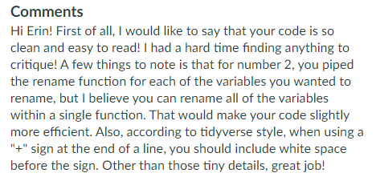